# A6: Event Study

Havisha Khurana

2025-02-20

## Event Studys

An event study estimates the impact of an event on an outcome over time. The typical difference-in-differences (DiD) style event study is:

An event study can be described by the estimation of the model,
$$y_{it} = \alpha +
\sum_{t~\ne~T-1}\beta_t~(T_{it}=1) + \lambda_{i} + \mu_{t} +
e_{it}~,$$
where $y_{it}$ is the outcome of unit $i$ in period $t$, and $T_{it}$ captures treatment (in period $t$). (In the above notation, the summation is meant to imply that the omitted category is the period immediately prior to the onset of treatment.)

**Part 1.** Simulate a DGP in which treatment is imposed on a fraction of units in a panel. Produce an event study figure that represents the effect of treatment on outcomes.

In terms of target… your event study plot should look something like [this](https://www.dropbox.com/scl/fi/jd12zu7i3w1gwc9cs1bax/A6.png?rlkey=oqdmhdzg6y9et4yza5a139s0v&dl=0).

For canned packages, consider using something like `fixest::feols()` and `iplot::iplot()`. (*Be careful picking up the right interactions if you write your own code.*)

```r
library(fixest)
library(tidyverse)
```

**The DGP:**

```r
# setting time and individual parameters
n_t <- 20
n_i <- 50

# description of parameters
# difference between treatment and control group: beta_x
# diff between treated and untreated period: beta_tr
# effect of treatment in treated period: beta_xtr = 1
# effect of time/year - linear: beta_t = 0
# heterogeneous effect of time in treated period: beta_ttr = 0

simulate_panel <- function(seed = 1,
                           n_t,
                           n_i,
                           treatment_period = n_t/2,
                           beta_x = 1,
                           beta_xtr = 1,
                           beta_tr_t = 0,
                           beta_tr_c = 0,
                           beta_t_t = 0,
                           beta_t_c = 0,
                           beta_ttr_t = 0,
                           beta_ttr_c = 0,
                           beta_pre_t = 0,
                           beta_pre_c = 0,
                           pre_t_start = (n_t / 2 - 4),
                           pre_t_end = (n_t / 2 - 1),
                           tr_custom_flag = 0,
                           tr_custom = c(round(quantile(1:n_t))[2:4]),
                           snip_flag_early = 0,
                           snip_flag_late = 0,
                           heterogeneity_flag = 0) {

  cross <- tibble(
    i = 1:n_i,
    # assignment to treatment
    x = rep(0:1, each = n_i / 2),
    # length of the panel
    t_length = n_t,
    # If treatment early/negative selection
    t_pre_tr_trend = sample(c(pre_t_start:pre_t_end), n_i, replace = T),
    # If t is custom
    tr_custom_t = sample(tr_custom, n_i, replace = T),
    # custrom treatment effect
    beta_xtr_custom = sample(c(round(0.75*beta_xtr):round(2*beta_xtr)), n_i, replace = T),
    # snip at all
    snip = sample(c(0,1), n_i, replace = T, prob = c(0.5,0.5)),
    # snip how much
    snip_early = sample(1:round(quantile(1:n_t)[2]), n_i, replace = T),
    # snip how much
    snip_late = sample(round(quantile(1:n_t)[4]):n_t, n_i, replace = T),
    ei = rnorm(length(1:n_i), 0, 1)
  ) %>%
    # combine snip and snip_early and snip_late
    mutate(
      snip_early = snip*snip_early*snip_flag_early,
      snip_late = ifelse(snip*snip_flag_late == 0, 21, snip_late)) %>%
    rowwise() %>%
    # code heterogeneous effect
    mutate(
      beta_xtr = ifelse(heterogeneity_flag != 0, beta_xtr_custom, beta_xtr)
    ) %>%
    ungroup()

  year <- tibble(t = 1:n_t, # year-level error term
                 et = rnorm(length(1:n_t), 0, 1))


  panel <- plyr::ddply(cross, ~ i, transform, t = 1:t_length) %>%
    left_join(year, by = "t") %>%
    mutate(
      # error term
      eit = rnorm(length(1:(n_i * n_t)), 0, 1),
      # treatment time flag
      tr = case_when(
        tr_custom_flag == 0 & t >= treatment_period ~ 1,
        tr_custom_flag == 0 & t < treatment_period ~ 0,
        tr_custom_flag == 1 & t >= tr_custom_t ~ 1,
        tr_custom_flag == 1 & t < tr_custom_t ~ 0
      ),
      # treatment pre flag
      t_pre_tr_trend = case_when(
        (beta_pre_t != 0 | beta_pre_c != 0) & t < t_pre_tr_trend ~ 0,
        (beta_pre_t != 0 |
           beta_pre_c != 0) & t >= t_pre_tr_trend & t < treatment_period ~ 1,
        (beta_pre_t != 0 |
           beta_pre_c != 0) &  t >= treatment_period ~ 0,
        TRUE ~ 0
      ),
      xtr = x*tr,
      # with individual and time level errors
      # defining separately for treatment and control groups
      y = ifelse(
        x == 1,
        10 + beta_x * x + beta_tr_t * tr + beta_xtr * xtr + beta_t_t *
          t + beta_ttr_t * (t - treatment_period) * tr + beta_pre_t * t_pre_tr_trend+ eit + ei + et,
        10 + beta_x * x + beta_tr_c * tr + beta_xtr * xtr + beta_t_c *
          t + beta_ttr_c * t * tr + beta_pre_c * t_pre_tr_trend + eit + ei + et
      )
    ) %>%
    # remove data points in early or late phases
    filter(t > snip_early & t < snip_late)

  return(panel)

}
```

```r
gen_did_plot <- function(df, y_outcome, caption = "", factor_color = x, t_length = n_t, treatment_period = n_t/2){

  plot <- ggplot(df, aes(x = t, y = {{y_outcome}}, color = factor({{factor_color}}))) +
  geom_point(alpha = 0.2, size = 1) +
  geom_line(aes(group = i), alpha = 0.2) +
  geom_smooth(data = filter(df, t < treatment_period), method = "lm") +
  geom_smooth(data = filter(df, t >= treatment_period), method = "lm") +
  labs(
    x = "Time",
    y = "Outcome",
    color = "Treatment Group",
    caption = paste0("Data on ",max(df$i)," indviduals over ",max(df$t)," periods.")
  ) +
  scale_x_continuous(breaks = 1:t_length)+
  geom_vline(aes(xintercept = (treatment_period - 0.5)), color = "darkred", linetype = "dotted")+
  annotate(geom = "text", x = treatment_period - 1, y = quantile(df$y)[3], label = "Time of Treatment",color = "darkred", angle = 90, size = 2.5, alpha = 0.7)+
  scale_color_manual(values = rev(RColorBrewer::brewer.pal(4, "Dark2"))) +
  theme_classic() +
  theme(legend.position = "bottom")

  plot

}
```

```r
generate_event_study_estimate_plot <- function(df, t_ref = (n_t/2 - 1), tr_time = n_t/2, subtitle = ""){

  event_study_estimate_plot <- feols(y ~ i(t,x,ref = t_ref) | i + t, data =df) %>%
    broom::tidy(., conf.int = TRUE) %>%
  mutate(
    time = parse_number(term), # Extract numeric time
    scaled_time = time - t_ref
  ) %>%
  ggplot(aes(x = scaled_time, y = estimate)) +
  geom_vline(xintercept = (tr_time - t_ref - 0.5), linetype = "dashed", color = "gray50") +  # Treatment line
  geom_hline(yintercept = 0, linetype = "solid", color = "gray70") +  # Reference line
  geom_point(color = "black", size = 1.5) +  # Point estimates
  geom_errorbar(aes(ymin = conf.low, ymax = conf.high), width = 0.2) +  # CI bars
  annotate("point", x = 0, y = 0, shape = 21, size = 2)+
  annotate("text", x = (tr_time - t_ref - 1), y = 2, label = "Treatment", color = "gray50", angle = 90)+
  #scale_x_continuous(breaks = range(.$scaled_time))+
  labs(
    title = "Event Study Coefficient Plot",
    subtitle = subtitle,
    x = "Time Period",
    y = "Estimated Coefficient",
    caption = paste0("Data on ",max(df$i)," indviduals over ",max(df$t)," periods.")
  ) +
  theme_classic()

  return(event_study_estimate_plot)
}
```

### **(o)** all assumptions meet…

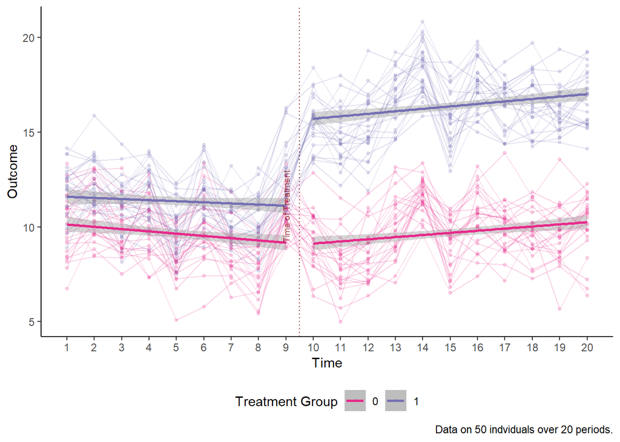

```r
panel_well_behaved <- simulate_panel(seed = 10,n_t = n_t, n_i = n_i, beta_xtr = 5)
gen_did_plot(panel_well_behaved,y)
```

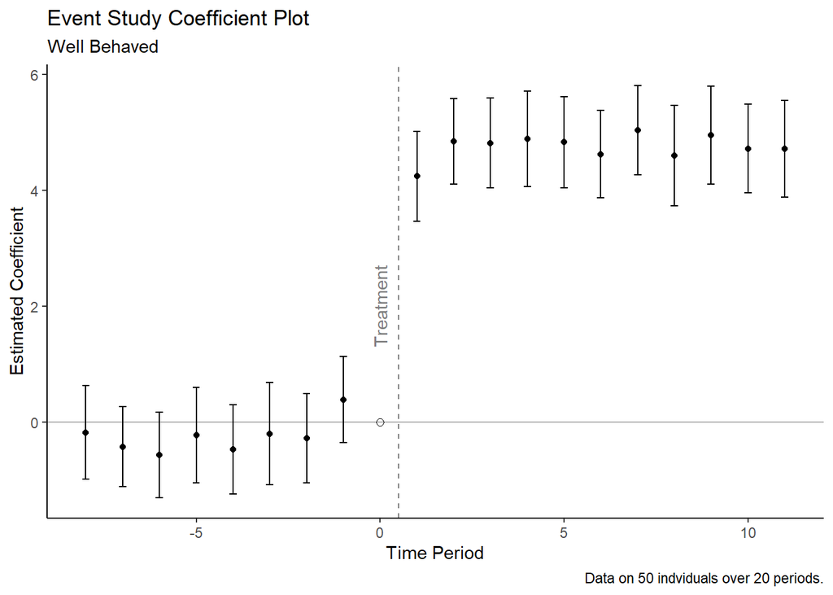

```r
generate_event_study_estimate_plot(panel_well_behaved,
                                   subtitle = "Well Behaved")
```

**Part 2:** Build into that DGP the following violations, in each case showing event-study plot that results from such a violation.

### **(i)** non-parallel trends…

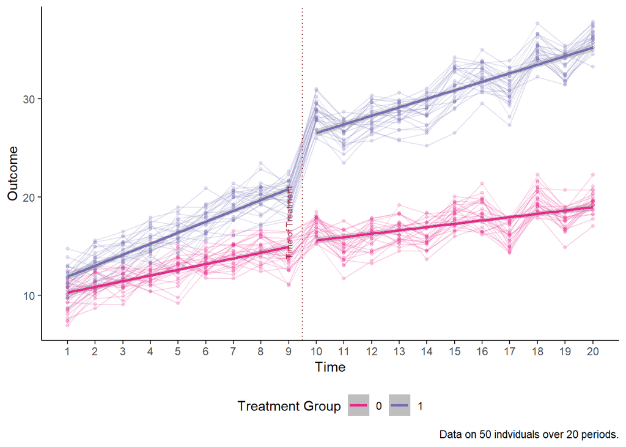

```r
panel_non_parallel <- simulate_panel(seed = 10,n_t = n_t, n_i = n_i, beta_xtr = 5,
                            beta_t_t = 1, beta_t_c = 0.5)
gen_did_plot(panel_non_parallel,y)
```

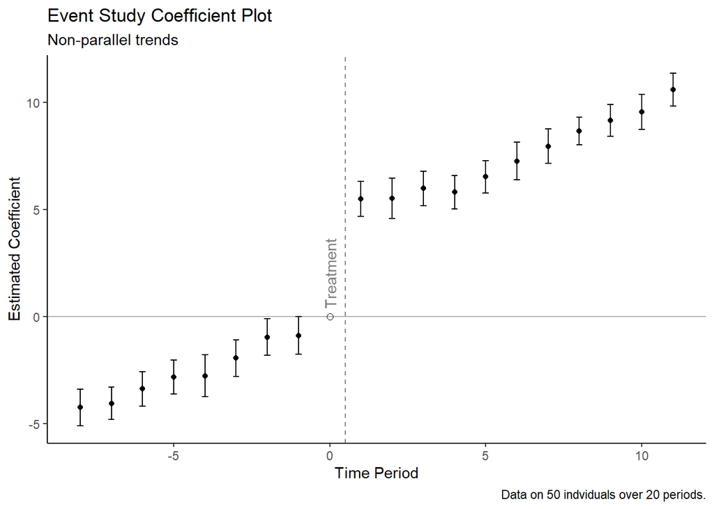

```r
generate_event_study_estimate_plot(panel_non_parallel,
                                   subtitle = "Non-parallel trends")
```

If there are non-parallel trends, we can see the event study estimates in the pre-period being different.

### **(ii)** parallel pre-treatment trends, with trends diverging in post treatment periods…

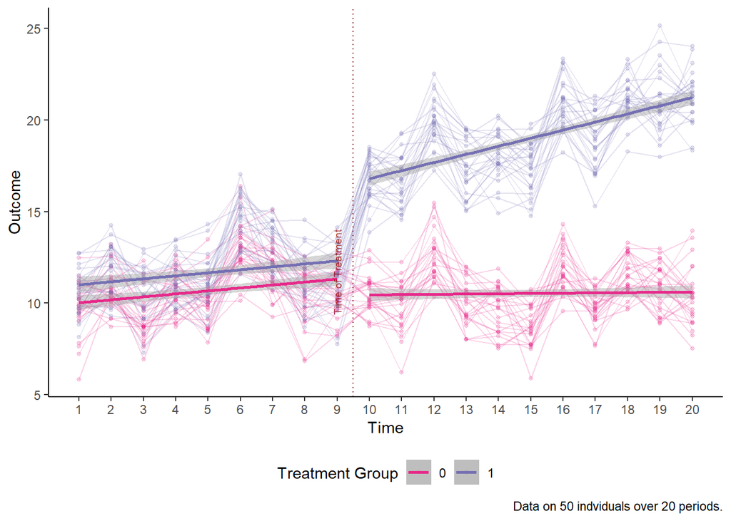

```r
panel_non_parallel_post <- simulate_panel(seed = 10,n_t = n_t, n_i = n_i, beta_xtr = 5,
                            beta_ttr_t = 0.5, beta_ttr_c = 0)
gen_did_plot(panel_non_parallel_post,y)
```

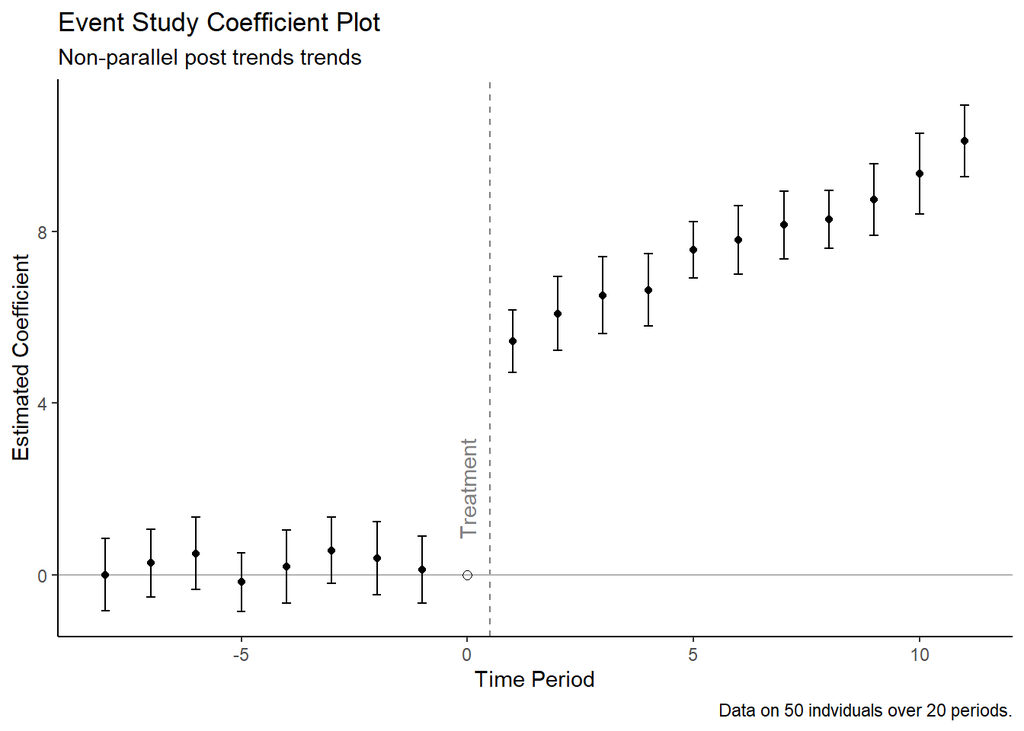

```r
generate_event_study_estimate_plot(panel_non_parallel_post,
                                   subtitle = "Non-parallel post trends trends")
```

If there are non-parallel trends in the post period, event study estimates seem to be rising in the post-period.

### **(iii)** an Ashenfelter dip…

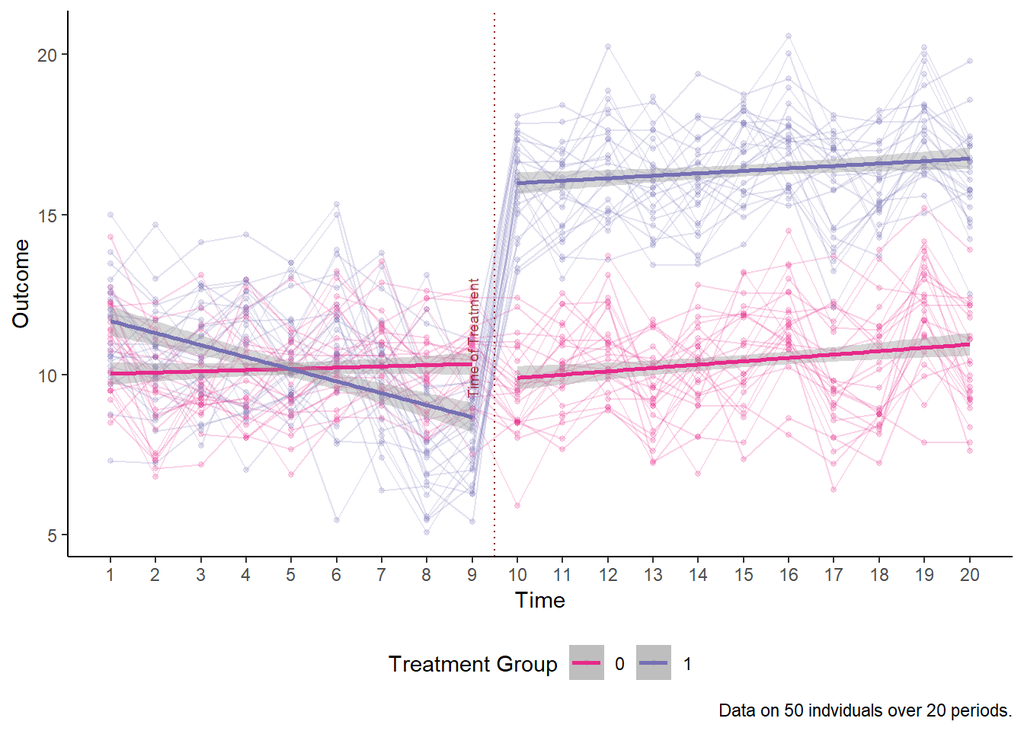

```r
panel_ashenfelter <- simulate_panel(seed = 10,n_t = n_t, n_i = n_i, beta_xtr = 5,
                            beta_pre_t = -3, beta_pre_c = 0)
gen_did_plot(panel_ashenfelter,y)
```

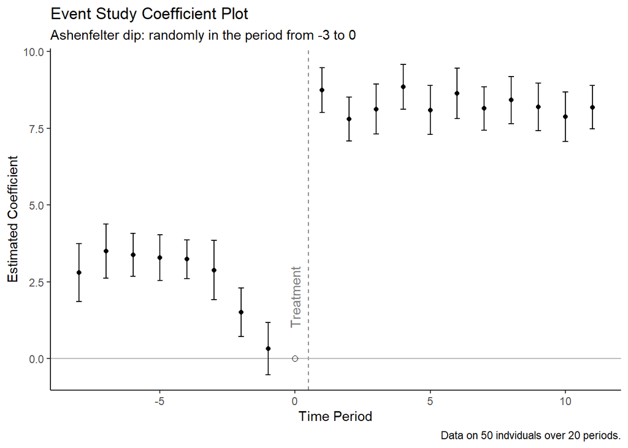

```r
generate_event_study_estimate_plot(panel_ashenfelter,
                                   subtitle = "Ashenfelter dip: randomly in the period from -3 to 0")
```

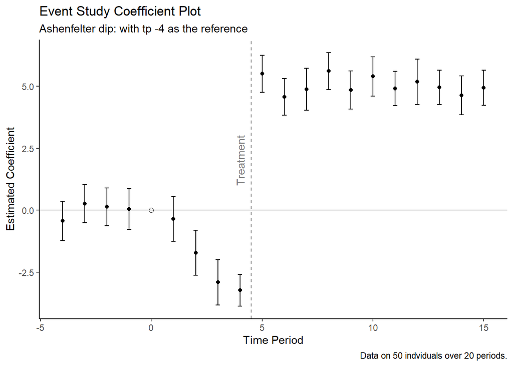

```r
generate_event_study_estimate_plot(panel_ashenfelter,
                                   t_ref = 5,
                                   subtitle = "Ashenfelter dip: with tp -4 as the reference")
```

If there is an Ashenfelter dip, all estimates of other time periods seem to be larger.

### **(iv)** a treatment that is anticipated (in a way that has units “responding” before it arrives)…

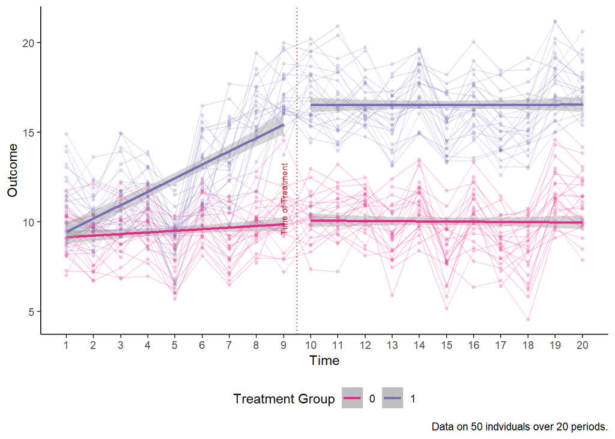

```r
panel_anticipated <- simulate_panel(seed = 10,n_t = n_t, n_i = n_i, beta_xtr = 5,
                            beta_pre_t = 5, beta_pre_c = 0)
gen_did_plot(panel_anticipated,y)
```

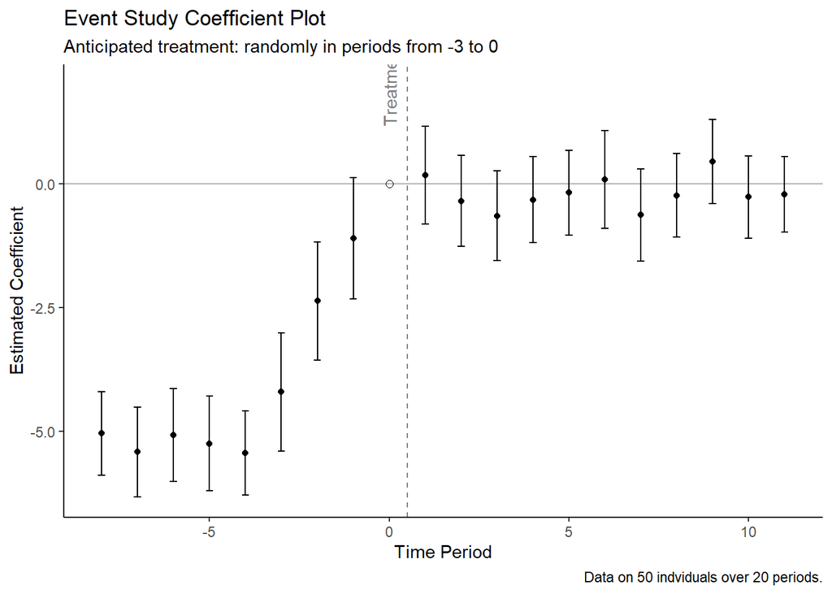

```r
generate_event_study_estimate_plot(panel_anticipated,
                                   subtitle = "Anticipated treatment: randomly in periods from -3 to 0")
```

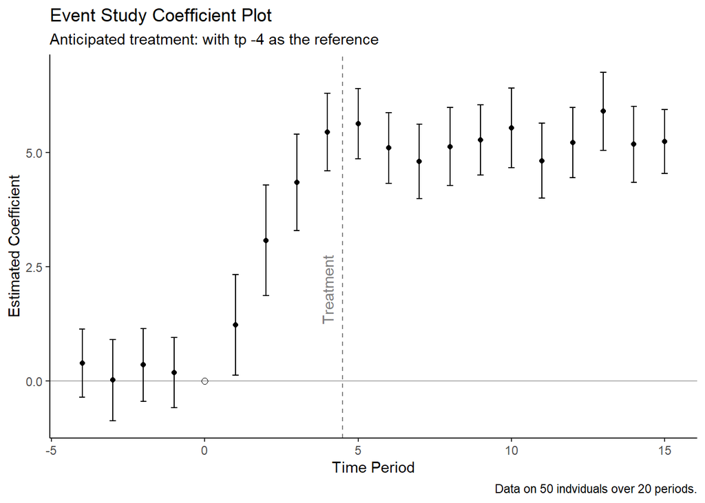

```r
generate_event_study_estimate_plot(panel_anticipated,
                                   t_ref = 5,
                                   subtitle = "Anticipated treatment: with tp -4 as the reference")
```

If there is an anticipated treatment effect, the reference estimate and treatment estimate don’t look different. Plus, the previous year estimates look lower.

### **(v)** unbalanced data (in a way that has units missing early or late in the time series)…

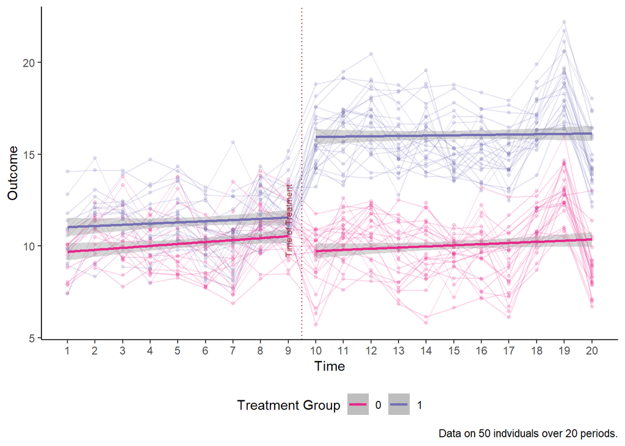

```r
panel_unbalanced_early <- simulate_panel(seed = 10,n_t = n_t, n_i = n_i, beta_xtr = 5, snip_flag_early = 1, snip_flag_late = 0)
gen_did_plot(panel_unbalanced_early,y)
```

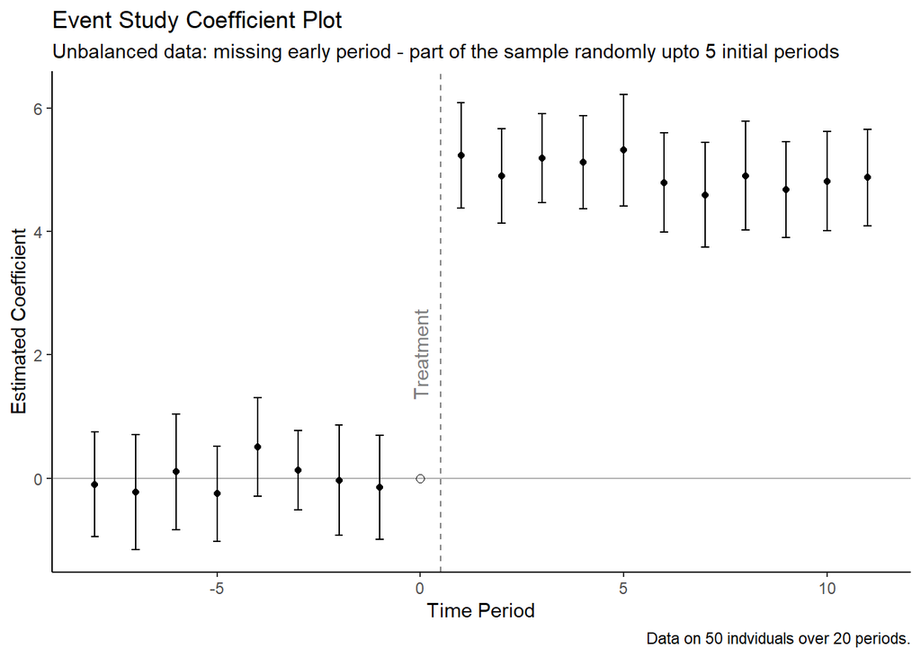

```r
generate_event_study_estimate_plot(panel_unbalanced_early,
                                   subtitle = "Unbalanced data: missing early period - part of the sample randomly upto 5 initial periods")
```

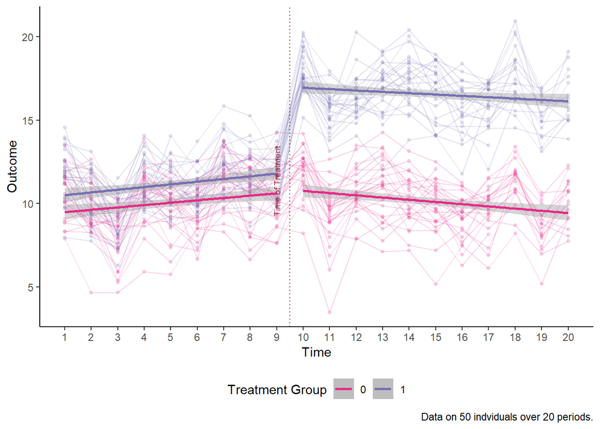

```r
panel_unbalanced_late <- simulate_panel(seed = 10,n_t = n_t, n_i = n_i, beta_xtr = 5, snip_flag_early = 0, snip_flag_late = 1)
gen_did_plot(panel_unbalanced_late,y)
```

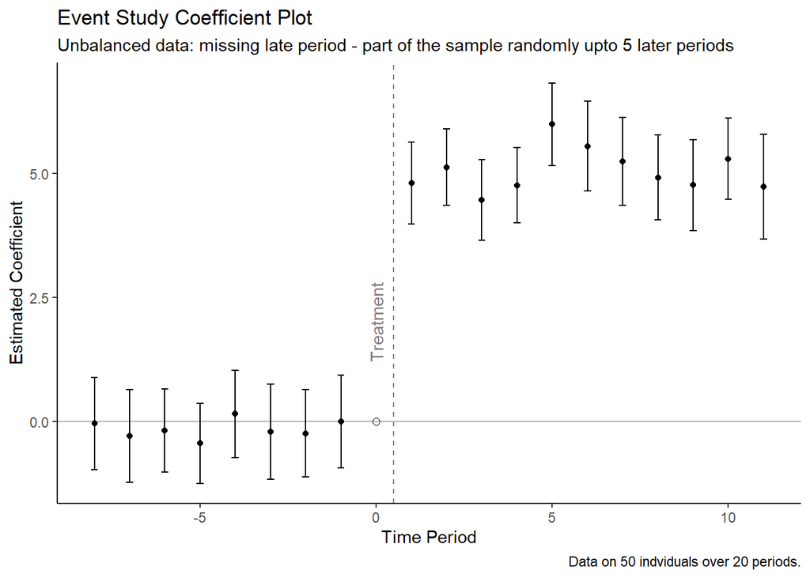

```r
generate_event_study_estimate_plot(panel_unbalanced_late,
                                   subtitle = "Unbalanced data: missing late period - part of the sample randomly upto 5 later periods")
```

```r
# generate_event_study_estimate_plot(panel_unbalanced,
#                                    t_ref = 6,
#                                    subtitle = "Anticipated treatment")
```

If missing observation for previous periods, then the standard error estimates are larger.

### **(vi)** among the treated, differential timing in treatment’s arrival…

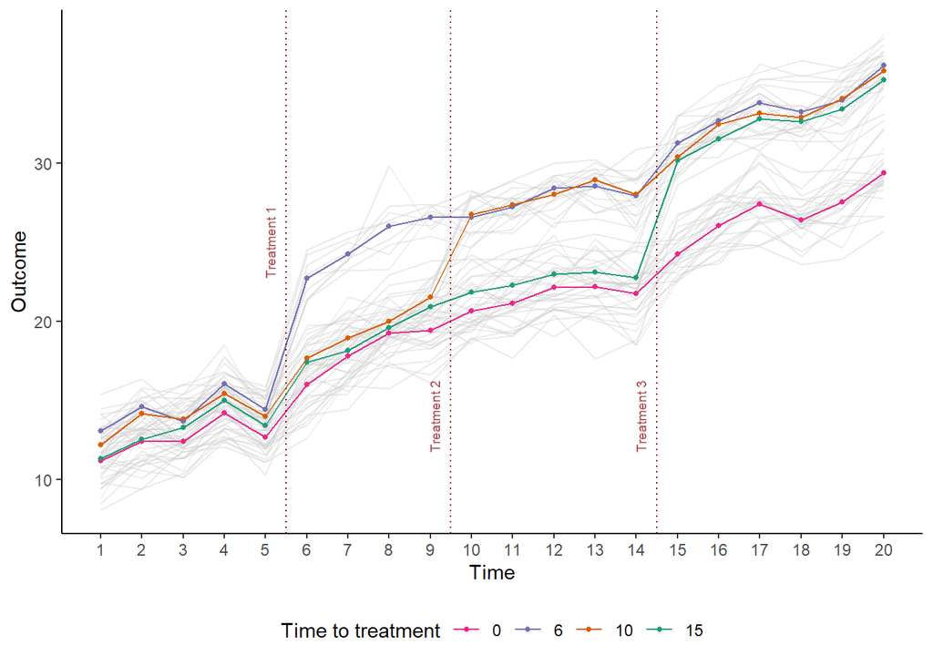

```r
panel_differential_time <- simulate_panel(seed = 20,n_t = n_t, n_i = n_i, beta_xtr = 5, tr_custom_flag = 1, beta_t_t = 1, beta_t_c = 1)

panel_differential_time %>%
  group_by(x*tr_custom_t, t) %>%
  summarize(mean_y = mean(y)) %>%
  ggplot(.,
       aes(x = t, y = mean_y, color = factor(`x * tr_custom_t`), group = factor(`x * tr_custom_t`))) +
  geom_line(data = panel_differential_time, aes(group = i, y = y), alpha = 0.4, color = "gray80") +
  geom_point(alpha = 1, size = 1) +
  geom_line(alpha = 1) +
  labs(
    x = "Time",
    y = "Outcome",
    color = "Time to treatment",
    #caption = caption
  ) +
  scale_x_continuous(breaks = 1:20)+
  geom_vline(aes(xintercept = 5.5), color = "darkred", linetype = "dotted")+
  geom_vline(aes(xintercept = 9.5), color = "darkred", linetype = "dotted")+
  geom_vline(aes(xintercept = 14.5), color = "darkred", linetype = "dotted")+
  annotate(geom = "text", x = 5.1, y = 25, label = "Treatment 1",color = "darkred", angle = 90, size = 2.5, alpha = 0.7)+
  annotate(geom = "text", x = 9.1, y = 14, label = "Treatment 2",color = "darkred", angle = 90, size = 2.5, alpha = 0.7)+
  annotate(geom = "text", x = 14.1, y = 14, label = "Treatment 3",color = "darkred", angle = 90, size = 2.5, alpha = 0.7)+
  scale_color_manual(values = rev(RColorBrewer::brewer.pal(4, "Dark2"))) +
  theme_classic() +
  theme(legend.position = "bottom")
```

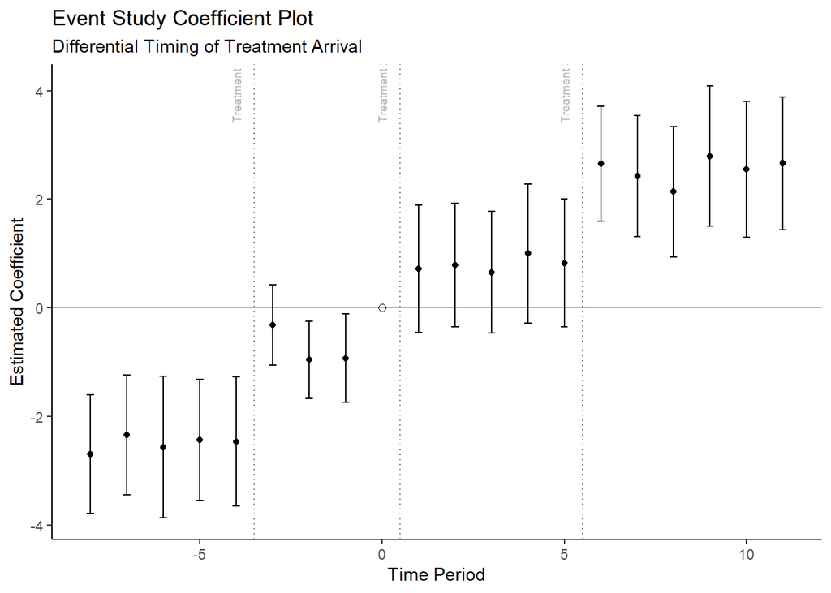

```r
feols(y ~ i(t,x,ref = 9) | i + t, data =panel_differential_time) %>%
    broom::tidy(., conf.int = TRUE) %>%
  mutate(
    time = parse_number(term), # Extract numeric time
    scaled_time = time - 9
  ) %>%
  ggplot(aes(x = scaled_time, y = estimate)) +
  # Treatment lines
  geom_vline(aes(xintercept = -3.5), color = "gray50", linetype = "dotted")+
  geom_vline(aes(xintercept = 0.5), color = "gray50", linetype = "dotted")+
  geom_vline(aes(xintercept = 5.5), color = "gray50", linetype = "dotted") +
    annotate(geom = "text", x = -4, y = 4, label = "Treatment 1",color = "gray60", angle = 90, size = 2.5, alpha = 0.7)+
  annotate(geom = "text", x = 0, y =4, label = "Treatment 2",color = "gray60", angle = 90, size = 2.5, alpha = 0.7)+
  annotate(geom = "text", x = 5, y = 4, label = "Treatment 3",color = "gray60", angle = 90, size = 2.5, alpha = 0.7)+
  geom_hline(yintercept = 0, linetype = "solid", color = "gray70") +  # Reference line
  geom_point(color = "black", size = 1.5) +  # Point estimates
  geom_errorbar(aes(ymin = conf.low, ymax = conf.high), width = 0.2) +  # CI bars
  annotate("point", x = 0, y = 0, shape = 21, size = 2)+
  #annotate("text", x = (tr_time - t_ref - 1), y = 1.5, label = "Treatment", color = "gray50", angle = 90)+
  #scale_x_continuous(breaks = range(.$scaled_time))+
  labs(
    title = "Event Study Coefficient Plot",
    subtitle = "Differential Timing of Treatment Arrival",
    x = "Time Period",
    y = "Estimated Coefficient"
  ) +
  theme_classic()
```

When there is staggered treatment, the set of estimates look consistent over a period and then change.

### **(vii)** among the treated, heterogeneity in the treatment effect (not in arrival, but in magnitude)…

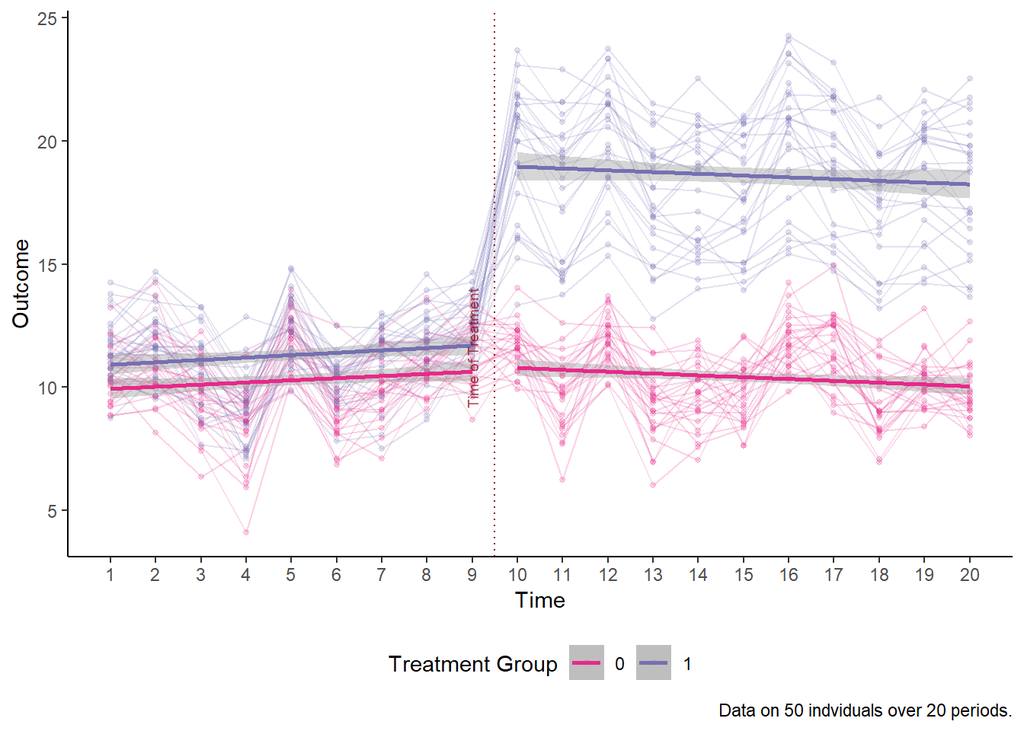

```r
panel_heterogeneous <- simulate_panel(seed = 10,n_t = n_t, n_i = n_i, beta_xtr = 5, heterogeneity_flag = 1)
gen_did_plot(panel_heterogeneous,y)
```

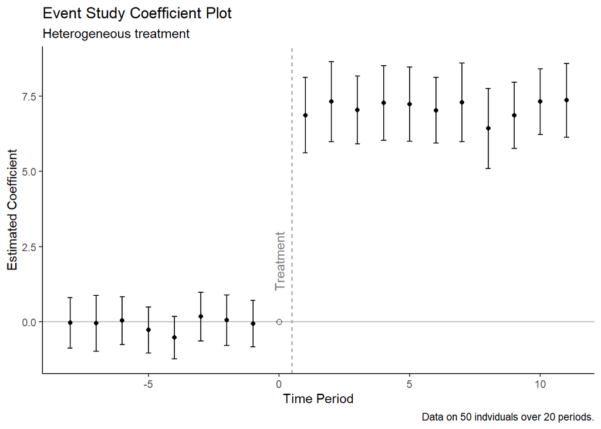

```r
generate_event_study_estimate_plot(panel_heterogeneous,
                                   subtitle = "Heterogeneous treatment")
```

If there is heterogeneous treatment effect, there would be more spread around the treatment effect estimate.